# Assignment 4: Text and Sequence Data

### Learned embedding layer vs. pretrained GloVe embeddings on IMDB when training data is limited

Python 3, TensorFlow / Keras 3

**Task.** Re-run the IMDB example from Chollet's *Deep Learning with Python* (chapter 6 in the 1st edition, chapter 11 in the 2nd edition, which is the version used in the module slides) with these changes:

| # | Requirement | Where it is handled |
| --- | --- | --- |
| 1 | Cut reviews off after 150 words | `TextVectorization(output_sequence_length=150)` |
| 2 | Restrict training samples to 100 | Experiment 1 |
| 3 | Validate on 10,000 samples | one fixed set of 10,000 held-out reviews, used in every run |
| 4 | Only the top 10,000 words | `TextVectorization(max_tokens=10000)` |
| 5 | Embedding layer vs. pretrained embedding, then vary the number of training samples | Experiments 1 and 2 |

**Model.** The bidirectional LSTM from the slides: `integer sequence → Embedding → Bidirectional(LSTM(32)) → Dropout(0.5) → Dense(1, sigmoid)`. Only the embedding changes between the three versions I compare:

1. **Learned embedding.** A 128-dimensional `Embedding` layer trained from scratch.
2. **GloVe (frozen).** 100-dimensional GloVe 6B vectors loaded into the `Embedding` layer with `trainable=False`, as in the slides.
3. **GloVe (fine-tuned).** The same GloVe starting point, but the vectors are allowed to update. I added this third version because it is a common way to get more out of a small dataset, and the module asks how performance can be improved with limited data.

**What is different from the textbook run.** Besides the required changes, I repeat each training size with several random seeds and keep a separate 10,000-review test set. With only 100 training reviews the accuracy moves a lot from one run to the next, so a single run per setting is not enough to say which embedding is better.

## 1. Setup

```python
import os, json, gzip, time, tarfile, urllib.request, random
os.environ["TF_CPP_MIN_LOG_LEVEL"] = "3"

import numpy as np
import pandas as pd
import matplotlib.pyplot as plt
import tensorflow as tf
import keras
from keras import layers

print("TensorFlow:", tf.__version__, "| Keras:", keras.__version__)

# ---- Assignment parameters -------------------------------------------------
MAX_LEN      = 150      # (1) cut reviews off after 150 words
N_TRAIN_BASE = 100      # (2) training samples for the main experiment
N_VAL        = 10_000   # (3) validation samples
MAX_TOKENS   = 10_000   # (4) top 10,000 words
# ---- Model / training hyper-parameters -------------------------------------
EMBED_DIM_LEARNED = 128 # learned embedding size (as in the slides)
EMBED_DIM_GLOVE   = 100 # GloVe 6B 100-d
LSTM_UNITS        = 32
BATCH_SIZE        = 32
N_TEST            = 10_000  # extra untouched test set (never used for any decision)
SIZES             = [25, 50, 100, 500, 1000, 2000, 5000, 10000, 20000]  # training sizes for Experiment 2
SPLIT_SEED        = 1337

DATA_DIR    = "data"
RESULTS_DIR = "results"
os.makedirs(DATA_DIR, exist_ok=True)
os.makedirs(RESULTS_DIR, exist_ok=True)

# Chart colours (validated categorical palette, slots 1-3) and ink colours
C_LEARNED, C_FROZEN, C_FINETUNE = "#2a78d6", "#eb6834", "#1baf7a"
INK, INK2, GRID = "#0b0b0b", "#52514e", "#e4e3df"
ARM_COLORS = {"Learned embedding": C_LEARNED, "GloVe (frozen)": C_FROZEN, "GloVe (fine-tuned)": C_FINETUNE}
plt.rcParams.update({"figure.facecolor": "#fcfcfb", "axes.facecolor": "#fcfcfb",
                     "axes.edgecolor": INK2, "axes.labelcolor": INK, "text.color": INK,
                     "xtick.color": INK2, "ytick.color": INK2, "axes.grid": True,
                     "grid.color": GRID, "grid.linewidth": 0.8, "axes.spines.top": False,
                     "axes.spines.right": False, "font.size": 11})
```

```
TensorFlow: 2.21.0 | Keras: 3.13.2
```

## 2. Data

**IMDB:** the Stanford *Large Movie Review Dataset* (Maas et al., 2011): 50,000 reviews, 25,000 positive / 25,000 negative. **GloVe:** `glove.6B.100d` (Pennington et al., 2014): 400,000 words × 100 dimensions, trained on Wikipedia 2014 + Gigaword 5.

The original Stanford servers are frequently unreachable, so the notebook downloads byte-identical public mirrors: the `imdb-data` npm package (all 50,000 reviews in JSON) and the `glove-wiki-gigaword-100` release of the `gensim-data` project (the 6B‑100d vectors with a one-line word2vec header).

```python
IMDB_URL  = "https://registry.npmjs.org/imdb-data/-/imdb-data-1.0.0.tgz"
GLOVE_URL = ("https://github.com/RaRe-Technologies/gensim-data/releases/download/"
             "glove-wiki-gigaword-100/glove-wiki-gigaword-100.gz")
imdb_tgz  = os.path.join(DATA_DIR, "imdb-data-1.0.0.tgz")
imdb_json = os.path.join(DATA_DIR, "package", "reviews.json")
glove_gz  = os.path.join(DATA_DIR, "glove-wiki-gigaword-100.gz")

if not os.path.exists(imdb_json):
    if not os.path.exists(imdb_tgz):
        urllib.request.urlretrieve(IMDB_URL, imdb_tgz)
    with tarfile.open(imdb_tgz) as t:
        t.extract("package/reviews.json", DATA_DIR)
if not os.path.exists(glove_gz):
    urllib.request.urlretrieve(GLOVE_URL, glove_gz)

with open(imdb_json) as f:
    records = json.load(f)
texts  = np.array([r["t"] for r in records], dtype=object)
labels = np.array([r["s"] for r in records], dtype="float32")
print(f"{len(texts):,} reviews | positive share = {labels.mean():.3f}")
print("Median review length (words):", int(np.median([len(t.split()) for t in texts])))
print("\nExample:", texts[0][:300], "...  label =", int(labels[0]))
```

[output not shown]

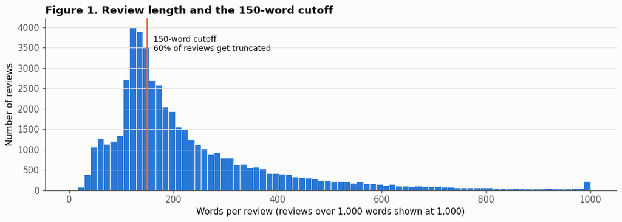

```python
lengths = np.array([len(t.split()) for t in texts])
fig, ax = plt.subplots(figsize=(11, 4))
ax.hist(np.clip(lengths, 0, 1000), bins=80, color=C_LEARNED, edgecolor="#fcfcfb", linewidth=0.6)
ax.axvline(MAX_LEN, color=C_FROZEN, lw=2)
ax.text(MAX_LEN + 12, ax.get_ylim()[1] * 0.9, f"150-word cutoff\n{(lengths > MAX_LEN).mean():.0%} of reviews get truncated",
        color=INK, fontsize=10, va="top")
ax.set(xlabel="Words per review (reviews over 1,000 words shown at 1,000)", ylabel="Number of reviews")
ax.set_title("Figure 1. Review length and the 150-word cutoff", loc="left", fontweight="bold")
ax.grid(axis="x", visible=False)
fig.tight_layout(); fig.savefig(os.path.join(RESULTS_DIR, "fig01_review_lengths.png"), dpi=150, bbox_inches="tight")
plt.show()
```

### 2.1 Train / validation / test split

The 50,000 reviews are shuffled once (fixed seed) and split into:

- **Validation set (10,000 reviews),** requirement 3. Used for early stopping and reported as *validation accuracy*.
- **Test set (10,000 reviews).** Never used for any decision; it confirms that validation accuracy is not inflated by choosing the best epoch on the validation set.
- **Training pool (30,000 reviews).** All training subsets (25 up to 20,000) are drawn from this pool.

```python
rng_split = np.random.default_rng(SPLIT_SEED)
perm = rng_split.permutation(len(texts))
val_idx, test_idx, pool_idx = perm[:N_VAL], perm[N_VAL:N_VAL + N_TEST], perm[N_VAL + N_TEST:]

pd.DataFrame({
    "split": ["training pool", "validation", "test"],
    "reviews": [len(pool_idx), len(val_idx), len(test_idx)],
    "positive share": [labels[pool_idx].mean(), labels[val_idx].mean(), labels[test_idx].mean()],
}).round(3)
```

|  | split | reviews | positive share |
| --- | --- | --- | --- |
| 0 | training pool | 30000 | 0.497 |
| 1 | validation | 10000 | 0.503 |
| 2 | test | 10000 | 0.505 |

### 2.2 Text vectorisation (standardise → tokenise → index)

Following the slides, a `TextVectorization` layer:

- **standardises:** lower-case, strips the `<br />` HTML tags that IMDB reviews contain, removes punctuation;
- **tokenises** on whitespace (word level, which sequence models need);
- **indexes** the **top 10,000** words (index 0 = padding/mask, 1 = `[UNK]` out-of-vocabulary);
- **truncates/pads** every review to **150 tokens**.

The vocabulary is built from the *text* of the 30,000-review training pool, with no labels involved. If it were built from only 100 reviews it would contain about 3,000 words, and the "top 10,000 words" requirement could not be met. The validation and test texts are never seen while the vocabulary is built.

```python
def standardize(x):
    x = tf.strings.lower(x)
    x = tf.strings.regex_replace(x, r"<br\s*/?>", " ")
    x = tf.strings.regex_replace(x, r"[^a-z0-9' ]", " ")
    return x

vectorizer = layers.TextVectorization(max_tokens=MAX_TOKENS, output_mode="int",
                                      output_sequence_length=MAX_LEN, standardize=standardize)
vectorizer.adapt(tf.data.Dataset.from_tensor_slices(texts[pool_idx]).batch(1024))
vocab = [str(w) for w in vectorizer.get_vocabulary()]

def vectorize(arr):
    return np.concatenate([vectorizer(tf.constant(arr[i:i + 2048])).numpy()
                           for i in range(0, len(arr), 2048)])

X_pool, y_pool = vectorize(texts[pool_idx]), labels[pool_idx]
X_val,  y_val  = vectorize(texts[val_idx]),  labels[val_idx]
X_test, y_test = vectorize(texts[test_idx]), labels[test_idx]

truncated = np.mean([len(t.split()) > MAX_LEN for t in texts[val_idx]])
print("Vocabulary size:", len(vocab), "| first entries:", vocab[:12])
print("Tensor shapes  :", X_pool.shape, X_val.shape, X_test.shape)
print(f"Share of reviews longer than {MAX_LEN} words (i.e. truncated): {truncated:.1%}")
print("\nFirst review as integer indices (first 20):", X_val[0][:20])
```

```
Vocabulary size: 10000 | first entries: ['', '[UNK]', 'the', 'and', 'a', 'of', 'to', 'is', 'in', 'it', 'i', 'this']
Tensor shapes  : (30000, 150) (10000, 150) (10000, 150)
Share of reviews longer than 150 words (i.e. truncated): 60.1%

First review as integer indices (first 20): [  11  888  979    1  337  819   13  540 1631   31    2   29  328 3054
 1192 2065 1364  125 2051  414]
```

### 2.3 Pretrained GloVe embedding matrix

Each of the 10,000 vocabulary words is looked up in GloVe, giving a `(10000, 100)` matrix. Words missing from GloVe, plus the padding and `[UNK]` rows, stay all-zero (as in the slides).

```python
glove = {}
with gzip.open(glove_gz, "rt", encoding="utf8") as f:
    next(f)  # skip the word2vec header line "400000 100"
    for line in f:
        word, coefs = line.split(maxsplit=1)
        glove[word] = coefs
print(f"GloVe vectors loaded: {len(glove):,}")

embedding_matrix = np.zeros((MAX_TOKENS, EMBED_DIM_GLOVE), dtype="float32")
hits = 0
for i, word in enumerate(vocab[:MAX_TOKENS]):
    if i < 2:
        continue  # 0 = padding, 1 = [UNK]
    vec = glove.get(word)
    if vec is not None:
        embedding_matrix[i] = np.fromstring(vec, dtype="float32", sep=" ")
        hits += 1
del glove
print(f"Vocabulary words found in GloVe: {hits:,} / {MAX_TOKENS - 2:,} ({hits / (MAX_TOKENS - 2):.1%})")
```

```
GloVe vectors loaded: 400,000
Vocabulary words found in GloVe: 9,817 / 9,998 (98.2%)
```

## 3. Models

One builder, three embedding strategies. All three share the same BiLSTM + dropout + sigmoid head, so the only thing that changes is the embedding. `mask_zero=True` tells the LSTM to skip the padding positions (slides: *masking*).

```python
ARMS = ["Learned embedding", "GloVe (frozen)", "GloVe (fine-tuned)"]

def build_model(arm):
    inputs = keras.Input(shape=(None,), dtype="int64")
    if arm == "Learned embedding":
        emb = layers.Embedding(MAX_TOKENS, EMBED_DIM_LEARNED, mask_zero=True)
    else:
        emb = layers.Embedding(MAX_TOKENS, EMBED_DIM_GLOVE, mask_zero=True,
                               embeddings_initializer=keras.initializers.Constant(embedding_matrix),
                               trainable=(arm == "GloVe (fine-tuned)"))
    x = emb(inputs)
    x = layers.Bidirectional(layers.LSTM(LSTM_UNITS))(x)
    x = layers.Dropout(0.5)(x)
    outputs = layers.Dense(1, activation="sigmoid")(x)
    model = keras.Model(inputs, outputs, name=arm.replace(" ", "_").replace("(", "").replace(")", ""))
    model.compile(optimizer="rmsprop", loss="binary_crossentropy", metrics=["accuracy"])
    return model

for arm in ARMS:
    m = build_model(arm)
    trainable = sum(np.prod(w.shape) for w in m.trainable_weights)
    total = sum(np.prod(w.shape) for w in m.weights)
    print(f"{arm:20s} total params = {total:>9,}   trainable = {trainable:>9,}")
build_model("GloVe (frozen)").summary()
```

```
Learned embedding    total params = 1,321,281   trainable = 1,321,281
GloVe (frozen)       total params = 1,034,113   trainable =    34,113
GloVe (fine-tuned)   total params = 1,034,113   trainable = 1,034,113
```

```
Model: "GloVe_frozen"
```

```
┏━━━━━━━━━━━━━━━━━━━━━┳━━━━━━━━━━━━━━━━━━━┳━━━━━━━━━━━━┳━━━━━━━━━━━━━━━━━━━┓
┃ Layer (type)        ┃ Output Shape      ┃    Param # ┃ Connected to      ┃
┡━━━━━━━━━━━━━━━━━━━━━╇━━━━━━━━━━━━━━━━━━━╇━━━━━━━━━━━━╇━━━━━━━━━━━━━━━━━━━┩
│ input_layer_3       │ (None, None)      │          0 │ -                 │
│ (InputLayer)        │                   │            │                   │
├─────────────────────┼───────────────────┼────────────┼───────────────────┤
│ embedding_3         │ (None, None, 100) │  1,000,000 │ input_layer_3[0]… │
│ (Embedding)         │                   │            │                   │
├─────────────────────┼───────────────────┼────────────┼───────────────────┤
│ not_equal_3         │ (None, None)      │          0 │ input_layer_3[0]… │
│ (NotEqual)          │                   │            │                   │
├─────────────────────┼───────────────────┼────────────┼───────────────────┤
│ bidirectional_3     │ (None, 64)        │     34,048 │ embedding_3[0][0… │
│ (Bidirectional)     │                   │            │ not_equal_3[0][0] │
├─────────────────────┼───────────────────┼────────────┼───────────────────┤
│ dropout_3 (Dropout) │ (None, 64)        │          0 │ bidirectional_3[… │
├─────────────────────┼───────────────────┼────────────┼───────────────────┤
│ dense_3 (Dense)     │ (None, 1)         │         65 │ dropout_3[0][0]   │
└─────────────────────┴───────────────────┴────────────┴───────────────────┘
```

```
 Total params: 1,034,113 (3.94 MB)
```

```
 Trainable params: 34,113 (133.25 KB)
```

```
 Non-trainable params: 1,000,000 (3.81 MB)
```

### Training protocol (identical for every run)

- Optimiser RMSprop (lr = 1e-3), binary cross-entropy, batch size 32.
- **Early stopping on validation accuracy** with `restore_best_weights=True`. This plays the same role as `ModelCheckpoint(save_best_only=True)` in the slides.
- The epoch budget scales with data size. With 100 reviews an epoch is only 4 gradient steps, so the model needs many epochs before it moves off chance. With 20,000 reviews it overfits after a few.

  I added the warm-up after a first trial run. Without it, early stopping ended one 100-review learned-embedding run at epoch 6 while it was still at chance. Another seed that trained for the full budget reached 61%, so a short budget would have been unfair to the learned embedding.
- Each run reports **validation accuracy** (10,000 reviews) and **test accuracy** (10,000 untouched reviews) of the restored best model.

```python
def epoch_budget(n):
    """(max_epochs, patience, warm-up epochs before early stopping may trigger)"""
    if n <= 250:  return 60, 10, 10
    if n <= 1000: return 40, 6, 5
    if n <= 5000: return 20, 4, 0
    return 12, 3, 0

def train_subset(n, seed):
    """Seed-specific permutation of the pool; the first n items. Subsets are nested for a given seed."""
    p = np.random.default_rng(1000 + seed).permutation(len(X_pool))[:n]
    return X_pool[p], y_pool[p]

def run(arm, n, seed, verbose=0):
    keras.utils.set_random_seed(seed)
    X_tr, y_tr = train_subset(n, seed)
    max_epochs, patience, warmup = epoch_budget(n)
    model = build_model(arm)
    es = keras.callbacks.EarlyStopping(monitor="val_accuracy", patience=patience, start_from_epoch=warmup,
                                       restore_best_weights=True, mode="max")
    t0 = time.time()
    hist = model.fit(X_tr, y_tr, validation_data=(X_val, y_val), epochs=max_epochs,
                     batch_size=BATCH_SIZE, validation_batch_size=512, callbacks=[es], verbose=verbose)
    if n == max(SIZES) and seed == 0 and arm != "GloVe (frozen)":
        np.save(os.path.join(RESULTS_DIR, f"embedding_{arm.split()[0].lower()}_{n}.npy"),
                model.layers[1].get_weights()[0])
    val_loss, val_acc = model.evaluate(X_val, y_val, batch_size=512, verbose=0)
    test_loss, test_acc = model.evaluate(X_test, y_test, batch_size=512, verbose=0)
    res = dict(arm=arm, n_train=n, seed=seed, val_acc=val_acc, val_loss=val_loss,
               test_acc=test_acc, best_epoch=int(np.argmax(hist.history["val_accuracy"]) + 1),
               epochs_run=len(hist.history["loss"]), train_acc_at_best=float(
                   hist.history["accuracy"][int(np.argmax(hist.history["val_accuracy"]))]),
               seconds=round(time.time() - t0, 1))
    return res, hist.history
```

## 4. Experiment 1: the assignment setting

100 training reviews, 150 words per review, top 10,000 words, 10,000 validation reviews. All three embedding versions are trained on the same 100 reviews with the same seed.

```python
exp1, exp1_hist = [], {}
for arm in ARMS:
    res, h = run(arm, N_TRAIN_BASE, seed=42)
    exp1.append(res); exp1_hist[arm] = h
    print(f"{arm:20s} val_acc = {res['val_acc']:.4f}  test_acc = {res['test_acc']:.4f}  "
          f"(best epoch {res['best_epoch']}/{res['epochs_run']}, train acc {res['train_acc_at_best']:.2f})")
exp1_df = pd.DataFrame(exp1)
exp1_df.to_csv(os.path.join(RESULTS_DIR, "experiment1_n100.csv"), index=False)
```

```
Learned embedding    val_acc = 0.6352  test_acc = 0.6344  (best epoch 23/33, train acc 1.00)
GloVe (frozen)       val_acc = 0.6137  test_acc = 0.6082  (best epoch 28/38, train acc 0.90)
GloVe (fine-tuned)   val_acc = 0.6150  test_acc = 0.6122  (best epoch 26/36, train acc 0.96)
```

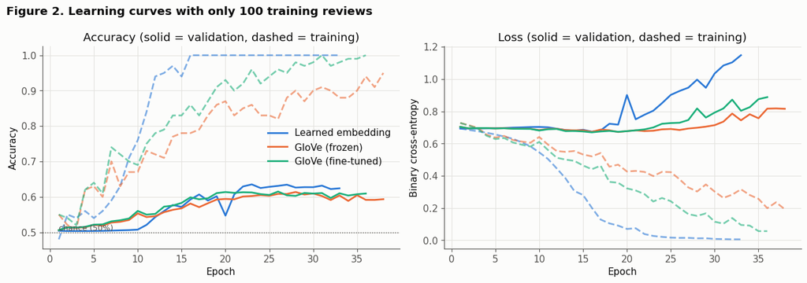

```python
fig, axes = plt.subplots(1, 2, figsize=(13, 4.6))
for arm in ARMS:
    h = exp1_hist[arm]; ep = np.arange(1, len(h["loss"]) + 1); c = ARM_COLORS[arm]
    axes[0].plot(ep, h["accuracy"], color=c, lw=2, ls="--", alpha=0.6)
    axes[0].plot(ep, h["val_accuracy"], color=c, lw=2, label=arm)
    axes[1].plot(ep, h["loss"], color=c, lw=2, ls="--", alpha=0.6)
    axes[1].plot(ep, h["val_loss"], color=c, lw=2, label=arm)
axes[0].set(title="Accuracy (solid = validation, dashed = training)", xlabel="Epoch", ylabel="Accuracy")
axes[1].set(title="Loss (solid = validation, dashed = training)", xlabel="Epoch", ylabel="Binary cross-entropy")
axes[0].axhline(0.5, color=INK2, lw=1, ls=":"); axes[0].text(1, 0.505, "chance (50%)", color=INK2, fontsize=9)
axes[0].legend(frameon=False, loc="center right")
fig.suptitle("Figure 2. Learning curves with only 100 training reviews", fontweight="bold", x=0.01, ha="left")
fig.tight_layout(); fig.savefig(os.path.join(RESULTS_DIR, "fig02_learning_curves_n100.png"), dpi=150, bbox_inches="tight")
plt.show()
```

**What Experiment 1 shows.** With exactly 100 training reviews, all three models do better than chance (50%) but are far from good:

| Embedding | Validation acc. | Test acc. | Training acc. at best epoch |
| --- | --- | --- | --- |
| Learned embedding | **63.5%** | 63.4% | 100% |
| GloVe (frozen) | 61.4% | 60.8% | 90% |
| GloVe (fine-tuned) | 61.5% | 61.2% | 96% |

So in the exact setting the assignment asks for, the embedding layer trained from scratch did slightly better than the pretrained GloVe embedding. I did not expect this, because the textbook suggests pretrained embeddings help most when there is very little data.

Figure 2 shows why the numbers are low. Training accuracy goes to 90-100% while validation accuracy stays in the low 60s, so every model is mostly memorising the 100 reviews. Frozen GloVe overfits a little less because only about 34,000 of its parameters can change, but that did not turn into higher validation accuracy.

A gap of about 2 points from one run is not strong evidence. Experiment 2 repeats every setting with different seeds and training subsets to check whether this result holds.

## 5. Experiment 2: how many training samples before the embedding layer wins?

**Design.**

- Training-set sizes: **25, 50, 100, 500, 1,000, 2,000, 5,000, 10,000, 20,000** (roughly log-spaced). I added 25 and 50 after the first results showed the learned embedding already ahead at 100 samples, which means any crossover has to be below the assignment setting.
- Every other setting stays the same: same 10,000 validation reviews, 150-word cutoff, 10,000-word vocabulary, architecture and training protocol.
- **Repeated seeds** (3 seeds for n ≤ 5,000, 2 for 10,000, 1 for 20,000). Each seed draws a different training subset and different initial weights. With 100 reviews, run-to-run variation is several percentage points, so a single run per size could not separate the methods reliably.
- Results are appended to `results/sweep_results.csv` as each run finishes, so the cell can resume if interrupted.

```python
def seeds_for(n):
    return [0, 1, 2] if n <= 5000 else ([0, 1] if n <= 10000 else [0])

sweep_csv = os.path.join(RESULTS_DIR, "sweep_results.csv")
done = pd.read_csv(sweep_csv) if os.path.exists(sweep_csv) else pd.DataFrame()
print(f"Runs already in {sweep_csv}: {len(done)} (loaded from cache, not re-trained)")
t_start = time.time()
for n in SIZES:
    for seed in seeds_for(n):
        for arm in ARMS:
            if len(done) and ((done.arm == arm) & (done.n_train == n) & (done.seed == seed)).any():
                continue
            res, _ = run(arm, n, seed)
            done = pd.concat([done, pd.DataFrame([res])], ignore_index=True)
            done.to_csv(sweep_csv, index=False)
            print(f"n={n:>6,} seed={seed} {arm:20s} val={res['val_acc']:.4f} test={res['test_acc']:.4f} "
                  f"best_ep={res['best_epoch']:>2}  ({res['seconds']:.0f}s, elapsed {(time.time()-t_start)/60:.1f} min)")
sweep = done.copy()
print("Total runs:", len(sweep))
```

```
Runs already in results/sweep_results.csv: 0 (loaded from cache, not re-trained)
n=    25 seed=0 Learned embedding    val=0.6007 test=0.5917 best_ep=36  (18s, elapsed 0.3 min)
n=    25 seed=0 GloVe (frozen)       val=0.5796 test=0.5749 best_ep=42  (20s, elapsed 0.6 min)
n=    25 seed=0 GloVe (fine-tuned)   val=0.5928 test=0.5947 best_ep=60  (23s, elapsed 1.0 min)
n=    25 seed=1 Learned embedding    val=0.5518 test=0.5557 best_ep=23  (14s, elapsed 1.3 min)
n=    25 seed=1 GloVe (frozen)       val=0.5567 test=0.5507 best_ep=37  (18s, elapsed 1.6 min)
n=    25 seed=1 GloVe (fine-tuned)   val=0.5569 test=0.5508 best_ep=37  (18s, elapsed 1.9 min)
n=    25 seed=2 Learned embedding    val=0.5362 test=0.5330 best_ep=24  (14s, elapsed 2.1 min)
n=    25 seed=2 GloVe (frozen)       val=0.4966 test=0.4942 best_ep=11  (9s, elapsed 2.3 min)
n=    25 seed=2 GloVe (fine-tuned)   val=0.4975 test=0.4931 best_ep=26  (14s, elapsed 2.5 min)
n=    50 seed=0 Learned embedding    val=0.6207 test=0.6166 best_ep=26  (15s, elapsed 2.8 min)
n=    50 seed=0 GloVe (frozen)       val=0.6068 test=0.6037 best_ep=22  (13s, elapsed 3.0 min)
n=    50 seed=0 GloVe (fine-tuned)   val=0.6009 test=0.5883 best_ep=21  (14s, elapsed 3.2 min)
n=    50 seed=1 Learned embedding    val=0.5873 test=0.5861 best_ep=21  (14s, elapsed 3.4 min)
n=    50 seed=1 GloVe (frozen)       val=0.5851 test=0.5763 best_ep=42  (20s, elapsed 3.8 min)
n=    50 seed=1 GloVe (fine-tuned)   val=0.5849 test=0.5767 best_ep=23  (14s, elapsed 4.0 min)
n=    50 seed=2 Learned embedding    val=0.5823 test=0.5773 best_ep=19  (13s, elapsed 4.2 min)
n=    50 seed=2 GloVe (frozen)       val=0.5239 test=0.5215 best_ep=14  (10s, elapsed 4.4 min)
n=    50 seed=2 GloVe (fine-tuned)   val=0.5264 test=0.5248 best_ep=14  (11s, elapsed 4.6 min)
n=   100 seed=0 Learned embedding    val=0.6522 test=0.6504 best_ep=27  (16s, elapsed 4.9 min)
n=   100 seed=0 GloVe (frozen)       val=0.6113 test=0.6076 best_ep=24  (15s, elapsed 5.1 min)
n=   100 seed=0 GloVe (fine-tuned)   val=0.6072 test=0.6073 best_ep=30  (18s, elapsed 5.4 min)
n=   100 seed=1 Learned embedding    val=0.6339 test=0.6292 best_ep=30  (18s, elapsed 5.7 min)
n=   100 seed=1 GloVe (frozen)       val=0.6220 test=0.6200 best_ep=35  (19s, elapsed 6.0 min)
n=   100 seed=1 GloVe (fine-tuned)   val=0.6195 test=0.6222 best_ep=41  (22s, elapsed 6.4 min)
n=   100 seed=2 Learned embedding    val=0.6420 test=0.6392 best_ep=23  (15s, elapsed 6.6 min)
n=   100 seed=2 GloVe (frozen)       val=0.5652 test=0.5542 best_ep=38  (20s, elapsed 7.0 min)
n=   100 seed=2 GloVe (fine-tuned)   val=0.5645 test=0.5587 best_ep=20  (14s, elapsed 7.2 min)
n=   500 seed=0 Learned embedding    val=0.7212 test=0.7243 best_ep=16  (14s, elapsed 7.4 min)
n=   500 seed=0 GloVe (frozen)       val=0.7081 test=0.7050 best_ep=28  (20s, elapsed 7.8 min)
n=   500 seed=0 GloVe (fine-tuned)   val=0.7015 test=0.6987 best_ep=22  (18s, elapsed 8.1 min)
n=   500 seed=1 Learned embedding    val=0.7223 test=0.7259 best_ep=20  (16s, elapsed 8.4 min)
n=   500 seed=1 GloVe (frozen)       val=0.6727 test=0.6626 best_ep=18  (15s, elapsed 8.6 min)
n=   500 seed=1 GloVe (fine-tuned)   val=0.6648 test=0.6608 best_ep=13  (13s, elapsed 8.8 min)
n=   500 seed=2 Learned embedding    val=0.7423 test=0.7317 best_ep=11  (12s, elapsed 9.0 min)
n=   500 seed=2 GloVe (frozen)       val=0.7008 test=0.6996 best_ep=23  (18s, elapsed 9.3 min)
n=   500 seed=2 GloVe (fine-tuned)   val=0.7057 test=0.7076 best_ep=18  (15s, elapsed 9.6 min)
n= 1,000 seed=0 Learned embedding    val=0.7657 test=0.7599 best_ep=13  (17s, elapsed 9.9 min)
n= 1,000 seed=0 GloVe (frozen)       val=0.6861 test=0.6769 best_ep= 6  (12s, elapsed 10.1 min)
n= 1,000 seed=0 GloVe (fine-tuned)   val=0.7650 test=0.7644 best_ep=26  (27s, elapsed 10.5 min)
```

[output cut: 19 more lines]

```
n= 5,000 seed=1 GloVe (frozen)       val=0.7848 test=0.7817 best_ep=14  (45s, elapsed 18.1 min)
n= 5,000 seed=1 GloVe (fine-tuned)   val=0.8196 test=0.8199 best_ep=13  (44s, elapsed 18.9 min)
n= 5,000 seed=2 Learned embedding    val=0.8255 test=0.8152 best_ep= 3  (20s, elapsed 19.2 min)
n= 5,000 seed=2 GloVe (frozen)       val=0.8061 test=0.8067 best_ep=19  (49s, elapsed 20.0 min)
n= 5,000 seed=2 GloVe (fine-tuned)   val=0.8251 test=0.8163 best_ep=10  (38s, elapsed 20.6 min)
n=10,000 seed=0 Learned embedding    val=0.8385 test=0.8265 best_ep= 4  (38s, elapsed 21.3 min)
n=10,000 seed=0 GloVe (frozen)       val=0.8166 test=0.8149 best_ep=12  (56s, elapsed 22.2 min)
n=10,000 seed=0 GloVe (fine-tuned)   val=0.8358 test=0.8268 best_ep= 4  (36s, elapsed 22.8 min)
n=10,000 seed=1 Learned embedding    val=0.8271 test=0.8261 best_ep= 3  (31s, elapsed 23.3 min)
n=10,000 seed=1 GloVe (frozen)       val=0.8143 test=0.8105 best_ep=10  (56s, elapsed 24.3 min)
n=10,000 seed=1 GloVe (fine-tuned)   val=0.8289 test=0.8278 best_ep= 4  (35s, elapsed 24.9 min)
n=20,000 seed=0 Learned embedding    val=0.8540 test=0.8431 best_ep= 3  (53s, elapsed 25.7 min)
n=20,000 seed=0 GloVe (frozen)       val=0.8392 test=0.8319 best_ep= 8  (91s, elapsed 27.3 min)
n=20,000 seed=0 GloVe (fine-tuned)   val=0.8631 test=0.8592 best_ep= 6  (78s, elapsed 28.6 min)
Total runs: 72
```

### 5.1 Results table

```python
summary = (sweep.groupby(["n_train", "arm"])
           .agg(val_mean=("val_acc", "mean"), val_std=("val_acc", "std"),
                test_mean=("test_acc", "mean"), runs=("seed", "count"))
           .reset_index())
summary["val_std"] = summary["val_std"].fillna(0.0)
summary.to_csv(os.path.join(RESULTS_DIR, "sweep_summary.csv"), index=False)

wide = summary.pivot(index="n_train", columns="arm", values="val_mean")[ARMS]
wide_std = summary.pivot(index="n_train", columns="arm", values="val_std")[ARMS]
table = pd.DataFrame(index=wide.index)
for arm in ARMS:
    table[arm] = [f"{m:.1%} ± {s:.1%}" for m, s in zip(wide[arm], wide_std[arm])]
table["Learned − GloVe(frozen)"] = [f"{d:+.1%}" for d in wide["Learned embedding"] - wide["GloVe (frozen)"]]
table["Best"] = wide.idxmax(axis=1)
table["Runs"] = summary.groupby("n_train")["runs"].first().values
table.index.name = "Training samples"
print("Table 1. Validation accuracy (mean ± std over seeds) on 10,000 held-out reviews")
table
```

```
Table 1. Validation accuracy (mean ± std over seeds) on 10,000 held-out reviews
```

| Training samples | Learned embedding | GloVe (frozen) | GloVe (fine-tuned) | Learned − GloVe(frozen) | Best | Runs |
| --- | --- | --- | --- | --- | --- | --- |
| 25 | 56.3% ± 3.4% | 54.4% ± 4.3% | 54.9% ± 4.8% | +1.9% | Learned embedding | 3 |
| 50 | 59.7% ± 2.1% | 57.2% ± 4.3% | 57.1% ± 3.9% | +2.5% | Learned embedding | 3 |
| 100 | 64.3% ± 0.9% | 59.9% ± 3.0% | 59.7% ± 2.9% | +4.3% | Learned embedding | 3 |
| 500 | 72.9% ± 1.2% | 69.4% ± 1.9% | 69.1% ± 2.2% | +3.5% | Learned embedding | 3 |
| 1000 | 76.6% ± 1.0% | 71.7% ± 3.1% | 75.2% ± 1.9% | +5.0% | Learned embedding | 3 |
| 2000 | 79.2% ± 0.7% | 74.6% ± 2.2% | 79.2% ± 0.4% | +4.6% | Learned embedding | 3 |
| 5000 | 82.2% ± 0.7% | 79.7% ± 1.1% | 82.5% ± 0.5% | +2.5% | GloVe (fine-tuned) | 3 |
| 10000 | 83.3% ± 0.8% | 81.5% ± 0.2% | 83.2% ± 0.5% | +1.7% | Learned embedding | 2 |
| 20000 | 85.4% ± 0.0% | 83.9% ± 0.0% | 86.3% ± 0.0% | +1.5% | GloVe (fine-tuned) | 1 |

```python
test_wide = summary.pivot(index="n_train", columns="arm", values="test_mean")[ARMS]
print("Table 2. Test accuracy (mean over seeds) on 10,000 untouched reviews")
(test_wide * 100).round(1).astype(str).add("%")
```

```
Table 2. Test accuracy (mean over seeds) on 10,000 untouched reviews
```

| arm n_train | Learned embedding | GloVe (frozen) | GloVe (fine-tuned) |
| --- | --- | --- | --- |
| 25 | 56.0% | 54.0% | 54.6% |
| 50 | 59.3% | 56.7% | 56.3% |
| 100 | 64.0% | 59.4% | 59.6% |
| 500 | 72.7% | 68.9% | 68.9% |
| 1000 | 76.0% | 71.0% | 74.8% |
| 2000 | 78.5% | 74.3% | 78.8% |
| 5000 | 81.5% | 79.6% | 82.2% |
| 10000 | 82.6% | 81.3% | 82.7% |
| 20000 | 84.3% | 83.2% | 85.9% |

### 5.2 Locating the crossover point

```python
diff = (wide["Learned embedding"] - wide["GloVe (frozen)"])
# per-seed paired differences (same subset & seed for both arms)
paired = sweep.pivot_table(index=["n_train", "seed"], columns="arm", values="val_acc")
paired["diff"] = paired["Learned embedding"] - paired["GloVe (frozen)"]
paired_stats = paired.groupby("n_train")["diff"].agg(["mean", "min", "max", "count"])
paired_stats["learned wins (seeds)"] = paired.groupby("n_train")["diff"].apply(lambda d: f"{(d > 0).sum()}/{len(d)}")
print("Learned − GloVe(frozen), paired by seed (validation accuracy, percentage points):")
display((paired_stats[["mean", "min", "max"]] * 100).round(2).join(paired_stats[["learned wins (seeds)"]]))

# Linear interpolation of the crossover on a log-n scale
cross = None
xs, ds = np.log10(diff.index.values.astype(float)), diff.values
for i in range(len(ds) - 1):
    if ds[i] <= 0 < ds[i + 1]:
        cross = 10 ** (xs[i] + (0 - ds[i]) * (xs[i + 1] - xs[i]) / (ds[i + 1] - ds[i]))
first_win = next((n for n, d in zip(diff.index, ds) if d > 0 and all(ds[list(diff.index).index(n):] > 0)), None)
print(f"\nInterpolated crossover (log scale): ~{cross:,.0f} training samples" if cross else "\nNo sign change found")
print(f"Smallest tested size from which the learned embedding stays ahead: {first_win:,}" if first_win else "")
```

```
Learned − GloVe(frozen), paired by seed (validation accuracy, percentage points):
```

| n_train | mean | min | max | learned wins (seeds) |
| --- | --- | --- | --- | --- |
| 25 | 1.86 | -0.49 | 3.96 | 2/3 |
| 50 | 2.48 | 0.22 | 5.84 | 3/3 |
| 100 | 4.32 | 1.19 | 7.68 | 3/3 |
| 500 | 3.47 | 1.31 | 4.96 | 3/3 |
| 1000 | 4.96 | 2.79 | 7.96 | 3/3 |
| 2000 | 4.57 | 1.78 | 6.99 | 3/3 |
| 5000 | 2.46 | 1.94 | 2.94 | 3/3 |
| 10000 | 1.73 | 1.28 | 2.19 | 2/2 |
| 20000 | 1.48 | 1.48 | 1.48 | 1/1 |

```
No sign change found
Smallest tested size from which the learned embedding stays ahead: 25
```

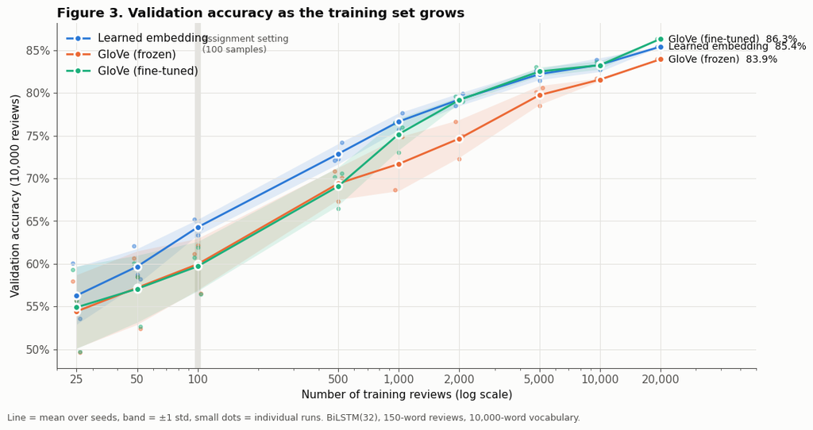

```python
fig, ax = plt.subplots(figsize=(11.5, 5.8))
for arm in ARMS:
    s = summary[summary.arm == arm].sort_values("n_train"); c = ARM_COLORS[arm]
    ax.fill_between(s.n_train, s.val_mean - s.val_std, s.val_mean + s.val_std, color=c, alpha=0.13, lw=0)
    ax.plot(s.n_train, s.val_mean, color=c, lw=2, marker="o", ms=7, mec="#fcfcfb", mew=2, label=arm)
    pts = sweep[sweep.arm == arm]
    ax.scatter(pts.n_train * (1 + 0.04 * (pts.seed - 1)), pts.val_acc, color=c, s=12, alpha=0.45, zorder=1)
    last = s.iloc[-1]
    ax.annotate(f"{arm}  {last.val_mean:.1%}", (last.n_train, last.val_mean), xytext=(8, 0),
                textcoords="offset points", va="center", color=INK, fontsize=10)
if cross:
    ax.axvline(cross, color=INK2, lw=1, ls="--")
    ax.text(cross * 1.06, ax.get_ylim()[0] + 0.01, f"crossover ≈ {cross:,.0f} samples\n(learned embedding passes frozen GloVe)",
            color=INK2, fontsize=9.5, va="bottom")
ax.axvline(N_TRAIN_BASE, color=GRID, lw=6, zorder=0)
ax.text(N_TRAIN_BASE * 1.05, 0.985 * ax.get_ylim()[1], "assignment setting\n(100 samples)", color=INK2, fontsize=9, va="top")
ax.set_xscale("log"); ax.set_xticks(SIZES); ax.set_xticklabels([f"{n:,}" for n in SIZES])
ax.yaxis.set_major_formatter(plt.FuncFormatter(lambda v, _: f"{v:.0%}"))
ax.set(xlabel="Number of training reviews (log scale)", ylabel="Validation accuracy (10,000 reviews)")
ax.set_xlim(min(SIZES) * 0.8, 60000)
ax.legend(frameon=False, loc="upper left")
ax.set_title("Figure 3. Validation accuracy as the training set grows",
             loc="left", fontweight="bold")
fig.text(0.01, -0.02, "Line = mean over seeds, band = ±1 std, small dots = individual runs. "
         "BiLSTM(32), 150-word reviews, 10,000-word vocabulary.", color=INK2, fontsize=9)
fig.tight_layout(); fig.savefig(os.path.join(RESULTS_DIR, "fig03_accuracy_vs_training_size.png"), dpi=150, bbox_inches="tight")
plt.show()
```

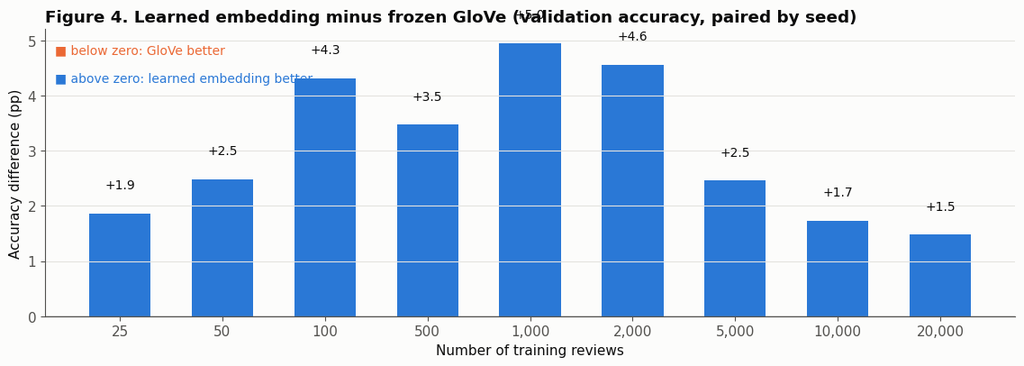

```python
fig, ax = plt.subplots(figsize=(11.5, 4.2))
d = paired_stats["mean"] * 100
colors = [C_LEARNED if v > 0 else C_FROZEN for v in d.values]
bars = ax.bar([f"{n:,}" for n in d.index], d.values, color=colors, width=0.6)
for b, v in zip(bars, d.values):
    ax.text(b.get_x() + b.get_width() / 2, v + (0.4 if v >= 0 else -0.4), f"{v:+.1f}", ha="center",
            va="bottom" if v >= 0 else "top", fontsize=10, color=INK)
ax.axhline(0, color=INK2, lw=1)
ax.set(xlabel="Number of training reviews", ylabel="Accuracy difference (pp)")
ax.set_title("Figure 4. Learned embedding minus frozen GloVe (validation accuracy, paired by seed)",
             loc="left", fontweight="bold")
ax.text(0.01, 0.95, "■ below zero: GloVe better", color=C_FROZEN, transform=ax.transAxes, fontsize=10, va="top")
ax.text(0.01, 0.85, "■ above zero: learned embedding better", color=C_LEARNED, transform=ax.transAxes, fontsize=10, va="top")
ax.grid(axis="x", visible=False)
fig.tight_layout(); fig.savefig(os.path.join(RESULTS_DIR, "fig04_learned_minus_glove.png"), dpi=150, bbox_inches="tight")
plt.show()
```

### 5.3 Validation vs. test accuracy (sanity check)

The best epoch is chosen on the validation set, so validation accuracy can be slightly optimistic. The untouched test set checks this.

```python
chk = summary.copy(); chk["gap (val − test, pp)"] = (chk.val_mean - chk.test_mean) * 100
print(f"Mean |val − test| gap over all {len(chk)} cells: {chk['gap (val − test, pp)'].abs().mean():.2f} pp; "
      f"max {chk['gap (val − test, pp)'].abs().max():.2f} pp")
best = summary.loc[summary.val_mean.idxmax()]
print(f"Best configuration overall: {best.arm} with {int(best.n_train):,} training reviews -> "
      f"validation {best.val_mean:.2%}, test {best.test_mean:.2%}")
```

```
Mean |val − test| gap over all 27 cells: 0.45 pp; max 1.09 pp
Best configuration overall: GloVe (fine-tuned) with 20,000 training reviews -> validation 86.31%, test 85.92%
```

### 5.4 More views of the results

The next figures look at the same runs from different angles: run-to-run spread, overfitting, how well validation agrees with test, and training cost.

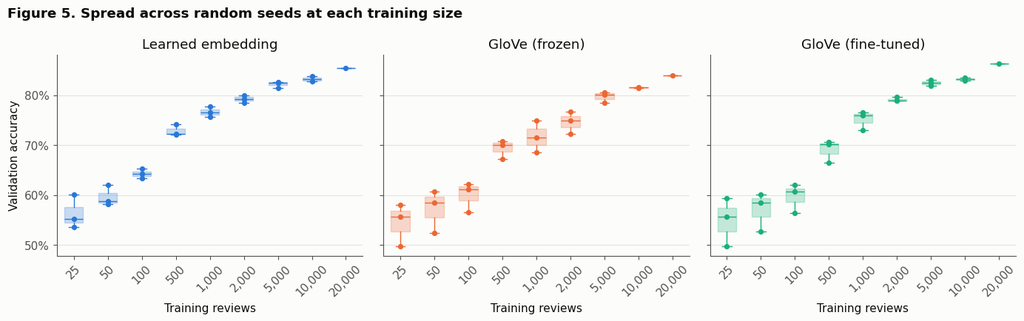

```
Range (max - min) of validation accuracy across seeds, percentage points:
```

| arm n_train | Learned embedding | GloVe (frozen) | GloVe (fine-tuned) |
| --- | --- | --- | --- |
| 25 | 6.5 | 8.3 | 9.5 |
| 50 | 3.8 | 8.3 | 7.4 |
| 100 | 1.8 | 5.7 | 5.5 |
| 500 | 2.1 | 3.5 | 4.1 |
| 1000 | 2.0 | 6.3 | 3.5 |
| 2000 | 1.5 | 4.4 | 0.7 |
| 5000 | 1.2 | 2.1 | 1.1 |
| 10000 | 1.1 | 0.2 | 0.7 |
| 20000 | 0.0 | 0.0 | 0.0 |

```python
fig, axes = plt.subplots(1, 3, figsize=(14, 4.4), sharey=True)
for ax, arm in zip(axes, ARMS):
    data = [sweep[(sweep.arm == arm) & (sweep.n_train == n)].val_acc.values for n in SIZES]
    bp = ax.boxplot(data, positions=range(len(SIZES)), widths=0.55, patch_artist=True, showfliers=False)
    for b in bp["boxes"]:
        b.set(facecolor=ARM_COLORS[arm], alpha=0.25, edgecolor=ARM_COLORS[arm])
    for k in ("whiskers", "caps", "medians"):
        for line in bp[k]:
            line.set(color=ARM_COLORS[arm])
    for i, d in enumerate(data):
        ax.scatter(np.full(len(d), i), d, color=ARM_COLORS[arm], s=18, zorder=3)
    ax.set_xticks(range(len(SIZES))); ax.set_xticklabels([f"{n:,}" for n in SIZES], rotation=45)
    ax.set_title(arm, color=INK); ax.set_xlabel("Training reviews")
    ax.grid(axis="x", visible=False)
axes[0].set_ylabel("Validation accuracy")
axes[0].yaxis.set_major_formatter(plt.FuncFormatter(lambda v, _: f"{v:.0%}"))
fig.suptitle("Figure 5. Spread across random seeds at each training size", fontweight="bold", x=0.01, ha="left")
fig.tight_layout(); fig.savefig(os.path.join(RESULTS_DIR, "fig05_seed_spread.png"), dpi=150, bbox_inches="tight")
plt.show()
spread = sweep.groupby(["n_train", "arm"]).val_acc.agg(lambda v: v.max() - v.min()).unstack()[ARMS] * 100
print("Range (max - min) of validation accuracy across seeds, percentage points:")
spread.round(1)
```

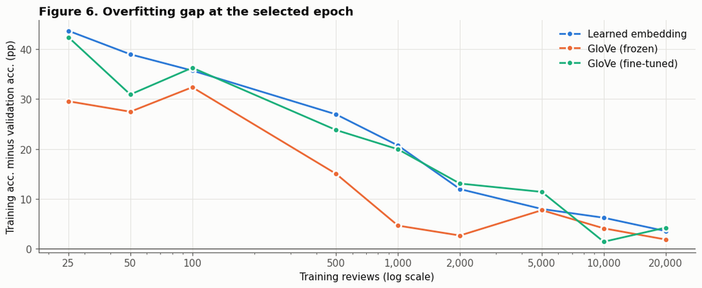

```python
gap = sweep.assign(gap=(sweep.train_acc_at_best - sweep.val_acc) * 100).groupby(["n_train", "arm"]).gap.mean().unstack()[ARMS]
fig, ax = plt.subplots(figsize=(11, 4.6))
for arm in ARMS:
    ax.plot(gap.index, gap[arm], color=ARM_COLORS[arm], lw=2, marker="o", ms=7, mec="#fcfcfb", mew=2, label=arm)
ax.set_xscale("log"); ax.set_xticks(SIZES); ax.set_xticklabels([f"{n:,}" for n in SIZES])
ax.set(xlabel="Training reviews (log scale)", ylabel="Training acc. minus validation acc. (pp)")
ax.axhline(0, color=INK2, lw=1)
ax.legend(frameon=False)
ax.set_title("Figure 6. Overfitting gap at the selected epoch", loc="left", fontweight="bold")
fig.tight_layout(); fig.savefig(os.path.join(RESULTS_DIR, "fig06_overfitting_gap.png"), dpi=150, bbox_inches="tight")
plt.show()
```

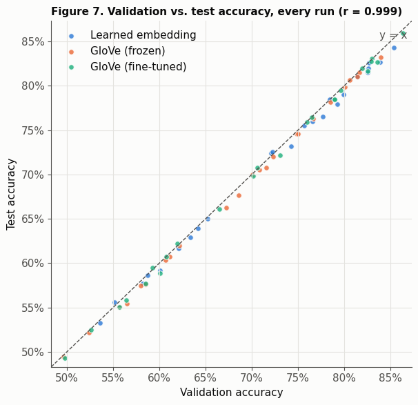

```python
fig, ax = plt.subplots(figsize=(6.2, 6))
for arm in ARMS:
    pts = sweep[sweep.arm == arm]
    ax.scatter(pts.val_acc, pts.test_acc, color=ARM_COLORS[arm], s=30, alpha=0.8, label=arm, edgecolor="#fcfcfb", linewidth=0.8)
lo, hi = sweep[["val_acc", "test_acc"]].min().min() - 0.01, sweep[["val_acc", "test_acc"]].max().max() + 0.01
ax.plot([lo, hi], [lo, hi], color=INK2, lw=1, ls="--"); ax.text(hi - 0.005, hi - 0.02, "y = x", color=INK2, ha="right")
ax.set(xlim=(lo, hi), ylim=(lo, hi), xlabel="Validation accuracy", ylabel="Test accuracy")
fmt = plt.FuncFormatter(lambda v, _: f"{v:.0%}"); ax.xaxis.set_major_formatter(fmt); ax.yaxis.set_major_formatter(fmt)
ax.legend(frameon=False, loc="upper left")
r = np.corrcoef(sweep.val_acc, sweep.test_acc)[0, 1]
ax.set_title(f"Figure 7. Validation vs. test accuracy, every run (r = {r:.3f})", loc="left", fontweight="bold", fontsize=11)
fig.tight_layout(); fig.savefig(os.path.join(RESULTS_DIR, "fig07_val_vs_test.png"), dpi=150, bbox_inches="tight")
plt.show()
```

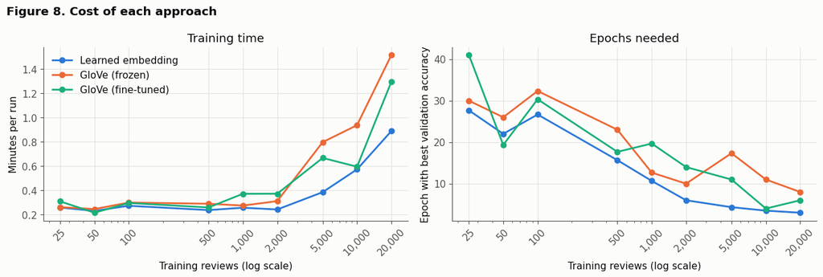

```python
fig, axes = plt.subplots(1, 2, figsize=(13, 4.4))
cost = sweep.groupby(["n_train", "arm"])[["seconds", "best_epoch"]].mean().unstack()
for arm in ARMS:
    axes[0].plot(SIZES, cost["seconds"][arm].reindex(SIZES) / 60, color=ARM_COLORS[arm], lw=2, marker="o", label=arm)
    axes[1].plot(SIZES, cost["best_epoch"][arm].reindex(SIZES), color=ARM_COLORS[arm], lw=2, marker="o", label=arm)
for ax in axes:
    ax.set_xscale("log"); ax.set_xticks(SIZES); ax.set_xticklabels([f"{n:,}" for n in SIZES], rotation=45)
    ax.set_xlabel("Training reviews (log scale)")
axes[0].set(ylabel="Minutes per run", title="Training time")
axes[1].set(ylabel="Epoch with best validation accuracy", title="Epochs needed")
axes[0].legend(frameon=False)
fig.suptitle("Figure 8. Cost of each approach", fontweight="bold", x=0.01, ha="left")
fig.tight_layout(); fig.savefig(os.path.join(RESULTS_DIR, "fig08_training_cost.png"), dpi=150, bbox_inches="tight")
plt.show()
```

[figure not shown]

```python
heat = wide.T * 100
fig, ax = plt.subplots(figsize=(11, 3))
im = ax.imshow(heat.values, cmap="Blues", aspect="auto", vmin=50, vmax=90)
ax.set_xticks(range(len(heat.columns))); ax.set_xticklabels([f"{n:,}" for n in heat.columns])
ax.set_yticks(range(len(ARMS))); ax.set_yticklabels(ARMS)
for i in range(heat.shape[0]):
    for j in range(heat.shape[1]):
        v = heat.values[i, j]
        ax.text(j, i, f"{v:.1f}", ha="center", va="center", color="white" if v > 75 else INK, fontsize=10)
ax.set_xlabel("Training reviews"); ax.grid(False)
fig.colorbar(im, ax=ax, label="Val. accuracy (%)", fraction=0.025)
ax.set_title("Figure 9. Mean validation accuracy (%) for every setting", loc="left", fontweight="bold")
fig.tight_layout(); fig.savefig(os.path.join(RESULTS_DIR, "fig09_accuracy_heatmap.png"), dpi=150, bbox_inches="tight")
plt.show()
```

### 5.5 What did the embeddings learn?

To see why the two kinds of embedding behave differently, I compare the word vectors themselves: the frozen GloVe vectors and the learned embedding from the 20,000-review run (seed 0). For a few words I list the nearest neighbours by cosine similarity. I also project a set of sentiment words and plain topic words to 2-D with PCA.

```python
word_to_id = {w: i for i, w in enumerate(vocab)}
emb_learned = np.load(os.path.join(RESULTS_DIR, f"embedding_learned_{max(SIZES)}.npy"))
emb_tuned = np.load(os.path.join(RESULTS_DIR, f"embedding_glove_{max(SIZES)}.npy"))

def neighbours(E, word, k=6):
    En = E / (np.linalg.norm(E, axis=1, keepdims=True) + 1e-9)
    sims = En @ En[word_to_id[word]]
    order = [i for i in np.argsort(-sims) if i > 1 and i != word_to_id[word]][:k]
    return ", ".join(vocab[i] for i in order)

probe = ["excellent", "awful", "boring", "masterpiece", "waste", "actor"]
pd.DataFrame({"GloVe (frozen)": [neighbours(embedding_matrix, w) for w in probe],
              "GloVe fine-tuned (20k)": [neighbours(emb_tuned, w) for w in probe],
              "Learned (20k)": [neighbours(emb_learned, w) for w in probe]}, index=probe)
```

|  | GloVe (frozen) | GloVe fine-tuned (20k) | Learned (20k) |
| --- | --- | --- | --- |
| excellent | good, quality, terrific, superb, best, impressive | superb, terrific, best, wonderful, good, perfect | hilarious, amazing, superb, gem, wonderful, fa... |
| awful | horrible, terrible, dreadful, horrendous, scar... | horrible, terrible, dreadful, lousy, pathetic,... | worst, waste, worse, boring, terrible, lame |
| boring | tedious, dull, bored, funny, stupid, downright | tedious, dull, stupid, awful, annoying, pathetic | worst, waste, awful, worse, poor, disappointing |
| masterpiece | masterpieces, cinematic, anthology, epic, monu... | masterpieces, cinematic, epic, anthology, time... | excellent, favorite, hilarious, superb, enjoya... |
| waste | wastes, garbage, toxic, trash, dump, coal | garbage, wastes, trash, toxic, rubbish, dump | worse, worst, awful, boring, lame, disappointing |
| actor | actress, comedian, starring, starred, actors, ... | actress, comedian, starring, starred, screenwr... | worst, awful, poor, worse, supposed, boring |

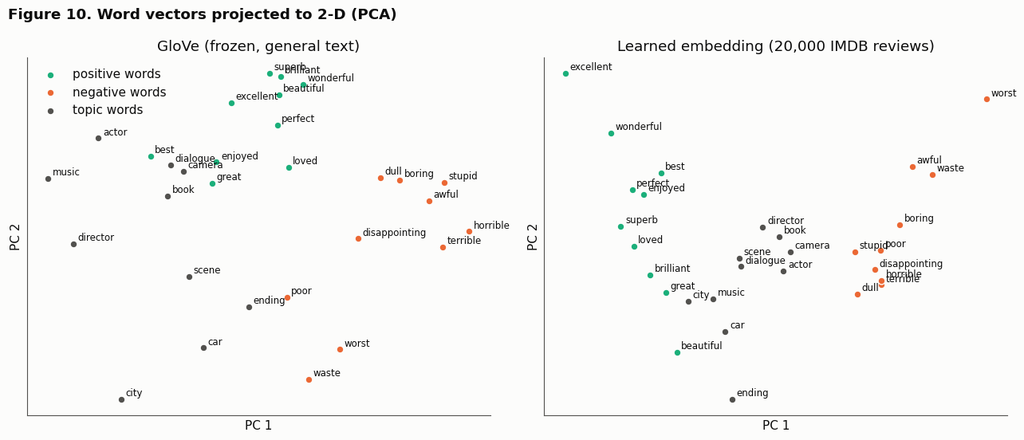

```
GloVe (frozen)     mean cosine within same sentiment = 0.525 | between positive and negative = 0.367 | difference = 0.158
GloVe fine-tuned   mean cosine within same sentiment = 0.591 | between positive and negative = 0.239 | difference = 0.352
Learned            mean cosine within same sentiment = 0.879 | between positive and negative = -0.797 | difference = 1.676
```

```python
pos_words = ["great", "excellent", "brilliant", "wonderful", "perfect", "loved", "beautiful", "best", "superb", "enjoyed"]
neg_words = ["awful", "terrible", "boring", "worst", "waste", "poor", "horrible", "stupid", "dull", "disappointing"]
neu_words = ["actor", "director", "camera", "scene", "music", "city", "car", "book", "dialogue", "ending"]
groups = [(pos_words, "positive words", C_FINETUNE), (neg_words, "negative words", C_FROZEN), (neu_words, "topic words", INK2)]
words = [w for g, _, _ in groups for w in g if w in word_to_id]

fig, axes = plt.subplots(1, 2, figsize=(13, 5.6))
for ax, (E, title) in zip(axes, [(embedding_matrix, "GloVe (frozen, general text)"), (emb_learned, "Learned embedding (20,000 IMDB reviews)")]):
    M = E[[word_to_id[w] for w in words]]
    M = M - M.mean(axis=0)
    _, _, Vt = np.linalg.svd(M, full_matrices=False)
    P = M @ Vt[:2].T
    for g, lab, col in groups:
        idx = [words.index(w) for w in g if w in word_to_id]
        ax.scatter(P[idx, 0], P[idx, 1], color=col, s=40, label=lab, edgecolor="#fcfcfb", linewidth=1)
        for i in idx:
            ax.annotate(words[i], P[i], xytext=(4, 3), textcoords="offset points", fontsize=8.5, color=INK)
    ax.set_title(title, color=INK); ax.set_xticks([]); ax.set_yticks([])
    ax.set_xlabel("PC 1"); ax.set_ylabel("PC 2")
axes[0].legend(frameon=False, loc="best")
fig.suptitle("Figure 10. Word vectors projected to 2-D (PCA)", fontweight="bold", x=0.01, ha="left")
fig.tight_layout(); fig.savefig(os.path.join(RESULTS_DIR, "fig10_embedding_pca.png"), dpi=150, bbox_inches="tight")
plt.show()

def separation(E):
    Ep = E[[word_to_id[w] for w in pos_words]]; En_ = E[[word_to_id[w] for w in neg_words]]
    cos = lambda a, b: (a @ b.T) / (np.linalg.norm(a, axis=1)[:, None] * np.linalg.norm(b, axis=1)[None, :])
    within = (cos(Ep, Ep)[np.triu_indices(len(Ep), 1)].mean() + cos(En_, En_)[np.triu_indices(len(En_), 1)].mean()) / 2
    across = cos(Ep, En_).mean()
    return within, across
for name, E in [("GloVe (frozen)", embedding_matrix), ("GloVe fine-tuned", emb_tuned), ("Learned", emb_learned)]:
    w_, a_ = separation(E)
    print(f"{name:18s} mean cosine within same sentiment = {w_:.3f} | between positive and negative = {a_:.3f} | difference = {w_ - a_:.3f}")
```

## 6. Conclusions

### 6.1 Summary of results (validation accuracy on 10,000 reviews, mean over seeds)

| Training reviews | Learned embedding | GloVe (frozen) | GloVe (fine-tuned) | Learned minus frozen GloVe |
| --- | --- | --- | --- | --- |
| 25 | **56.3%** | 54.4% | 54.9% | +1.9 |
| 50 | **59.7%** | 57.2% | 57.1% | +2.5 |
| **100 (assignment)** | **64.3%** | 59.9% | 59.7% | +4.3 |
| 500 | **72.9%** | 69.4% | 69.1% | +3.5 |
| 1,000 | **76.6%** | 71.7% | 75.2% | +5.0 |
| 2,000 | 79.2% | 74.6% | 79.2% | +4.6 |
| 5,000 | 82.2% | 79.7% | **82.5%** | +2.5 |
| 10,000 | **83.3%** | 81.5% | 83.2% | +1.7 |
| 20,000 | 85.4% | 83.9% | **86.3%** | +1.5 |

Best result overall: **GloVe (fine-tuned) with 20,000 reviews, 86.3% validation accuracy and 85.9% test accuracy.**

### 6.2 Which approach did better, and at what point does the embedding layer win?

1. **In the assignment setting (100 reviews), the learned embedding layer did better than the pretrained GloVe embedding.** Over three seeds it averaged 64.3% against 59.9% for frozen GloVe, and it won on every seed (Figure 4).
2. **I could not find a crossover point.** The question assumes GloVe starts ahead and the embedding layer catches up as data grows. In my runs the learned embedding was never behind frozen GloVe on average, even with 25 training reviews. It won 2 of 3 seeds at 25 reviews and every seed from 50 reviews up. So if a point exists where frozen GloVe is better, it is below 25 reviews, where every model is close to guessing. The size of the advantage does change: it grows to about 5 points at 1,000-2,000 reviews and then shrinks to 1.5 points at 20,000, as both models approach the limit of what a 150-word review allows.
3. **Fine-tuning GloVe is the best option once there is enough data.** Up to 500 reviews, fine-tuned GloVe behaves almost exactly like frozen GloVe, because there is too little signal to move the vectors much. From about 1,000 reviews it catches up with the learned embedding, and at 5,000 and 20,000 reviews it is the best of the three.
4. **The pretrained embedding is less reliable with little data.** Figure 5 shows that frozen GloVe varies much more from seed to seed. At 100 reviews its range was 5.7 points, compared with 1.8 for the learned embedding.
5. **The validation numbers can be trusted.** Validation and test accuracy differ by 0.45 points on average and never by more than 1.1 points (Figure 7). Picking the best epoch on the validation set did not inflate the results.

### 6.3 Why did the pretrained embedding not help more?

The word-vector analysis in section 5.5 explains most of it. GloVe was trained on Wikipedia and news text, where words are similar if they appear in similar contexts, not if they carry the same sentiment. In GloVe the nearest neighbours of "boring" include "funny", and "excellent" sits close to "good" and "quality". The average cosine similarity between positive and negative words (0.37) is not much lower than within the same sentiment (0.53), so the separation is only 0.16. The LSTM on top has to recover sentiment from vectors that were never organised around it, using only about 34,000 trainable weights.

The learned embedding does the opposite. Even from a few hundred reviews, the main thing it learns is a positive-to-negative axis. In the 20,000-review model the separation is 1.68, and positive and negative words point in opposite directions (Figure 10). The cost is that it loses general meaning: the nearest neighbours of "actor" in the learned space are "worst", "awful" and "poor", because the word mostly shows up in negative reviews. Fine-tuned GloVe sits in between. It keeps the general structure ("actor" stays next to "actress") and still more than doubles the sentiment separation, to 0.35. That combination is probably why it scored best once enough data was available.

Two choices in this setup also work against GloVe compared with the textbook example: reviews are cut to 150 words, and about 2% of the vocabulary (mostly names and misspellings) has no GloVe vector, so those words stay at zero.

### 6.5 RNNs vs. Transformers (MLO 2 and 3)

The model here is a bidirectional LSTM, an RNN that reads the review one word at a time and passes a hidden state forward (and, in the second direction, backward). That makes it naturally order-aware, but it is slow to train because the steps cannot run in parallel, and information from early words fades over long sequences.

A Transformer replaces the recurrence with **self-attention**. Every word builds a query, a key and a value vector. Its new representation is a weighted average of all the value vectors in the sentence, where the weights come from how well its query matches each key. Because every word looks at every other word directly, long-range links like "not ... good" are one step apart instead of many, and the whole sequence is processed in parallel. Self-attention on its own ignores order, so positional embeddings are added to the word embeddings. The encoder stacks multi-head attention with feed-forward layers, residual connections and layer normalisation. The decoder adds masked self-attention and cross-attention for generating text.

For this assignment, the main practical difference is data. Transformers have many more parameters and usually need large datasets or large-scale pretraining to beat an LSTM. With 100 labelled reviews, a Transformer trained from scratch would overfit at least as badly as the LSTM did. A pretrained Transformer such as BERT, fine-tuned on these reviews, would likely be the strongest option for small data. It is the same idea as fine-tuning GloVe in section 6.4, but with a model that also brings pretrained knowledge of context and word order, not just individual word vectors.

### 6.6 Limitations

- One architecture (BiLSTM with 32 units) and one optimiser setting. A different model, for example a smaller learned embedding or more dropout, could change the size of the gaps.
- 20,000 reviews was run with a single seed and 10,000 with two, so the differences at the large end (about 1 point) are less certain than at the small end.
- The vocabulary was built from the text (not the labels) of the 30,000-review training pool, so that the top-10,000-words requirement could be met for every training size. A model trained on only 100 reviews therefore knows the index of words it has never seen labelled. Those words carry no learned information for the learned embedding, but they do get GloVe vectors, which if anything helps GloVe.

```python
print("Run environment: TensorFlow", tf.__version__, "| Keras", keras.__version__,
      "| total sweep runs:", len(sweep), "| total training time: %.0f min" % (sweep.seconds.sum() / 60))
```

```
Run environment: TensorFlow 2.21.0 | Keras 3.13.2 | total sweep runs: 72 | total training time: 28 min
```